# Eric_Hirsch_624_Homework_6

```r
library(tidyverse)
library(tsibble)
library(fpp3)
library(EHData)
library(gridExtra)
library(fable)
```

1,2,3,5,6,7,8

*9.1 Figure 9.32 shows the ACFs for 36 random numbers, 360 random numbers and 1,000 random numbers.*

__9.1a Explain the differences among these figures. Do they all indicate that the data are white noise?*__

Yes, there is no patterning and no correlations exceed .05.

*9.1b Why are the critical values at different distances from the mean of zero? Why are the autocorrelations different in each figure when they each refer to white noise?.*

They are constructed from different sample sizes. The larger the sample, the more “white noise” the sample will be.

*9.2 A classic example of a non-stationary series are stock prices. Plot the daily closing prices for Amazon stock (contained in gafa_stock), along with the ACF and PACF. Explain how each plot shows that the series is non-stationary and should be differenced.*

The plot of the time series shows a clear trend upward. The ACF shows an extreme level of autocorrelation. The PACF shows the extreme degree to which each observation is correlated with the previous one.

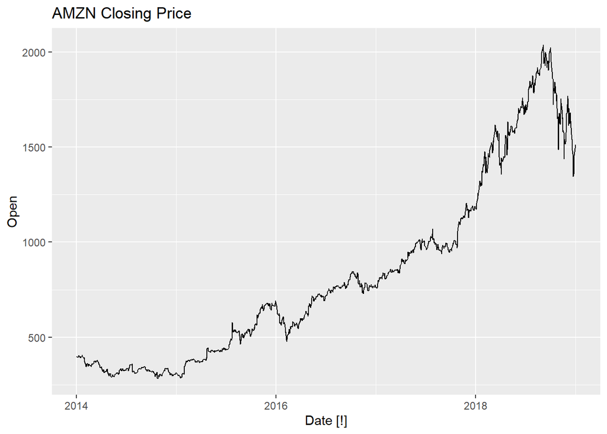

```r
tsAmazon <- gafa_stock %>%
  filter(Symbol=="AMZN")

  autoplot(tsAmazon) + labs(title = "AMZN Closing Price")
```

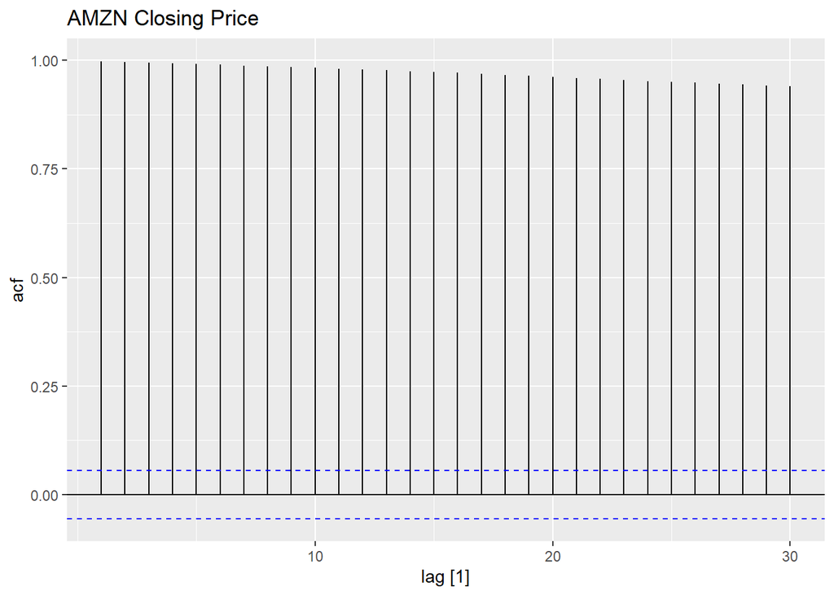

```r
tsAmazon |> ACF(Close) %>% autoplot() + labs(title="AMZN Closing Price")
```

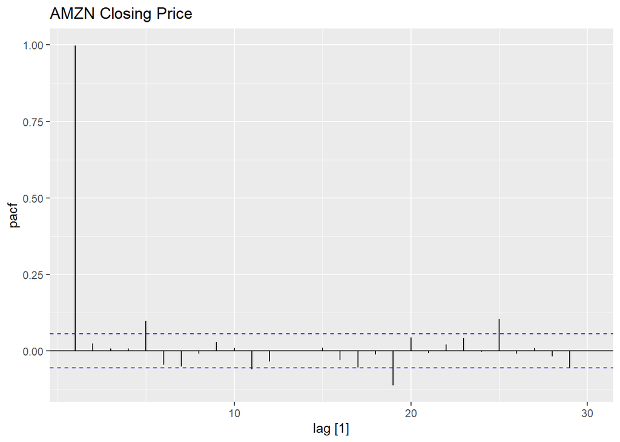

```r
tsAmazon |> PACF(Close) %>% autoplot() + labs(title="AMZN Closing Price")
```

*9.3 For the following series, find an appropriate Box-Cox transformation and order of differencing in order to obtain stationary data.*

__* 9.3a Turkish GDP from global_economy.*__

The boxcox transformation is not necessary to smooth the variance, but does make the curve more linear. One difference is all that is necessary to create a stationary series.

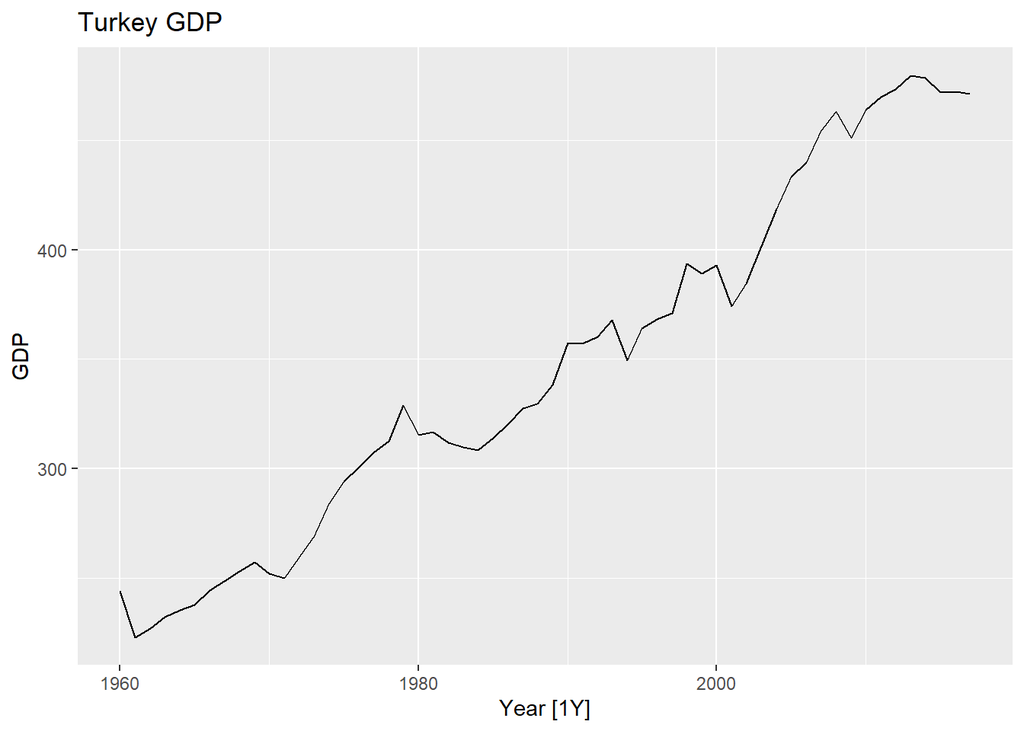

```r
Get_lambda <- function(ts, column) {
  lambda <- ts %>%
  features(ts[,column], features = guerrero) %>%
  pull(lambda_guerrero)

  return(lambda)

}

tsTurk <- global_economy %>%
  filter(Country=="Turkey")

tsTurk <- tsTurk |>  mutate(GDP=box_cox(GDP, Get_lambda(tsTurk, "GDP")))

  tsTurk %>% autoplot(GDP)+ labs(title="Turkey GDP")
```

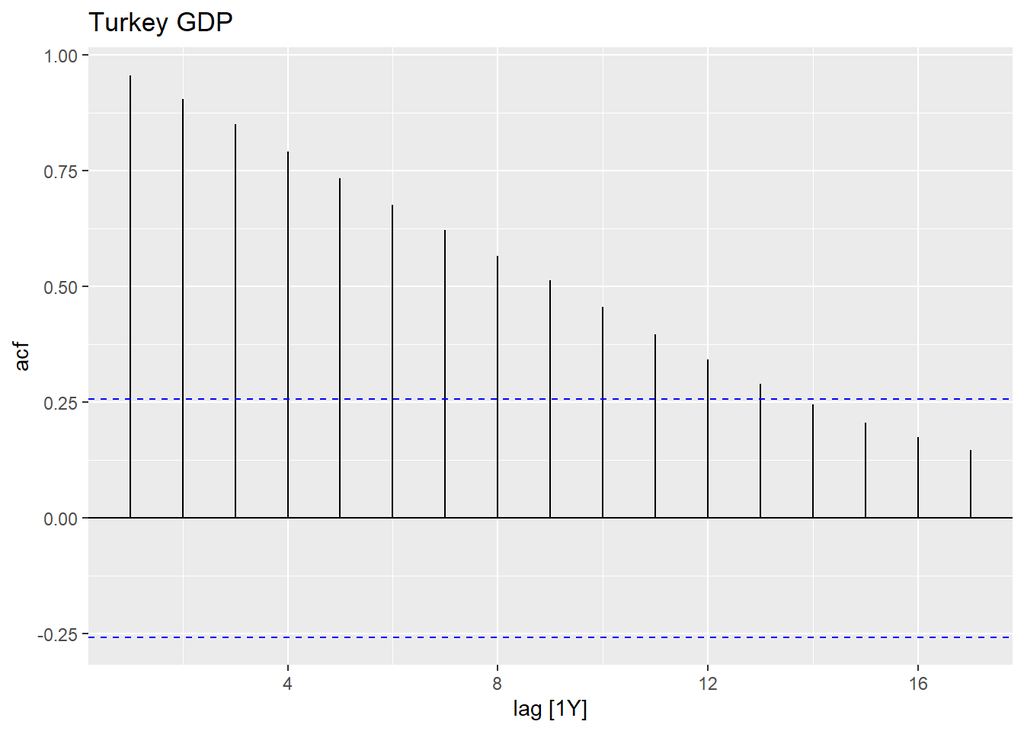

```r
  tsTurk |> ACF(GDP) %>% autoplot() + labs(title="Turkey GDP")
```

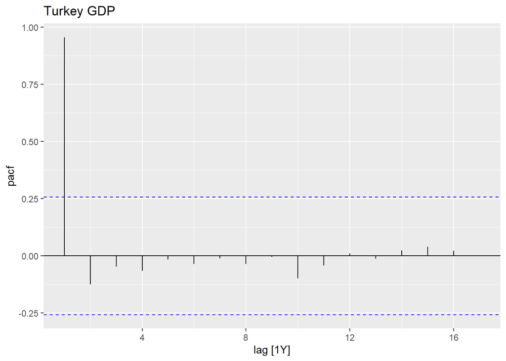

```r
  tsTurk |> PACF(GDP) %>% autoplot() + labs(title="Turkey GDP")
```

```r
  tsTurk |>
  mutate(diff_GDP = difference(GDP)) |>
  features(diff_GDP, ljung_box, lag = 10)
```

```
## # A tibble: 1 × 3
##   Country lb_stat lb_pvalue
##   <fct>     <dbl>     <dbl>
## 1 Turkey     5.84     0.829
```

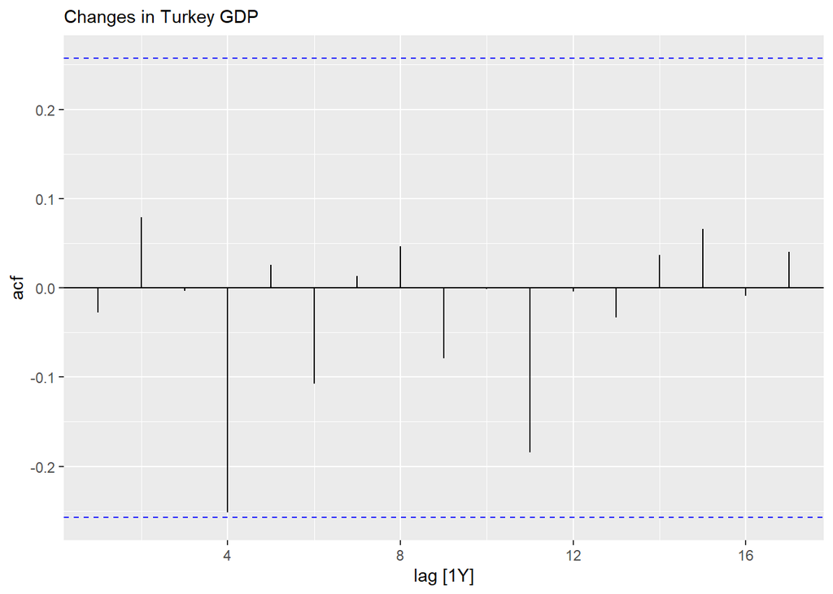

```r
  tsTurk |> ACF(difference(GDP)) |>
  autoplot() + labs(subtitle = "Changes in Turkey GDP")
```

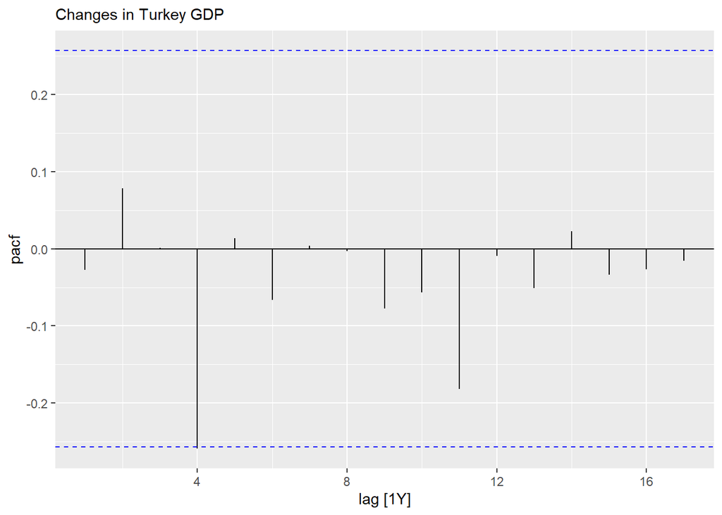

```r
  tsTurk |> PACF(difference(GDP)) |>
  autoplot() + labs(subtitle = "Changes in Turkey GDP")
```

```r
  tsTurk |>
  mutate(diff_GDP = difference(GDP)) |>
  features(diff_GDP, ljung_box, lag = 10)
```

```
## # A tibble: 1 × 3
##   Country lb_stat lb_pvalue
##   <fct>     <dbl>     <dbl>
## 1 Turkey     5.84     0.829
```

*9.3b Accommodation takings in the state of Tasmania from aus_accommodation.*

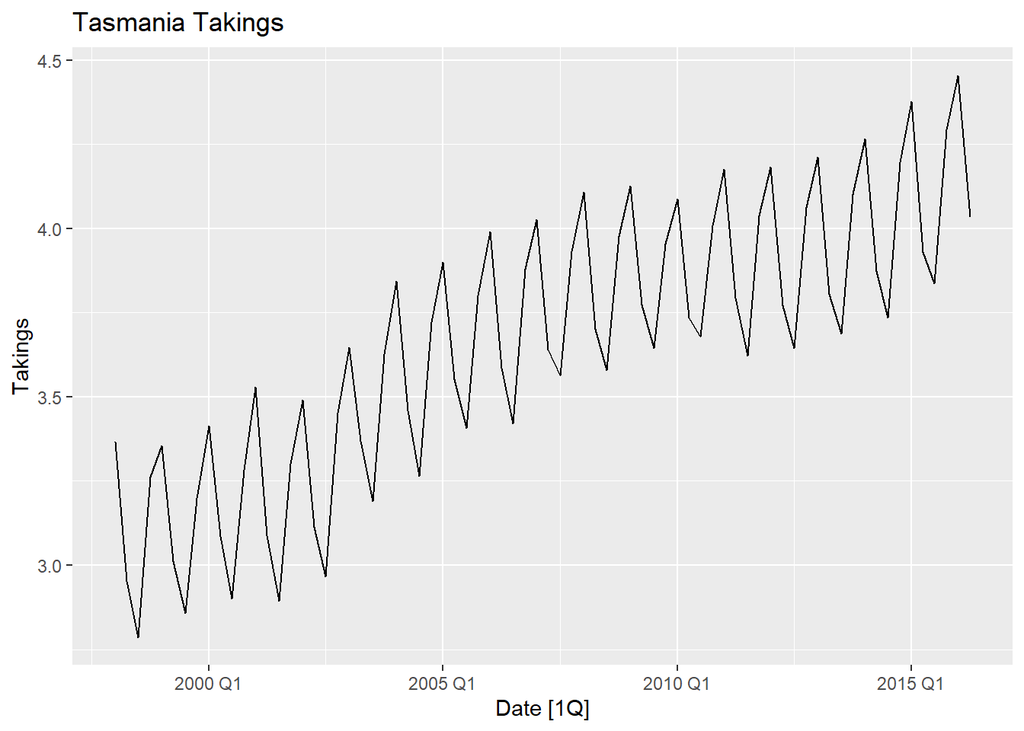

```r
tsAcc <- aus_accommodation %>%
  filter(State=="Tasmania")

tsAcc <- tsAcc |>  mutate(Takings=box_cox(Takings, Get_lambda(tsAcc, "Takings")))

  tsAcc %>% autoplot(Takings)+ labs(title="Tasmania Takings")
```

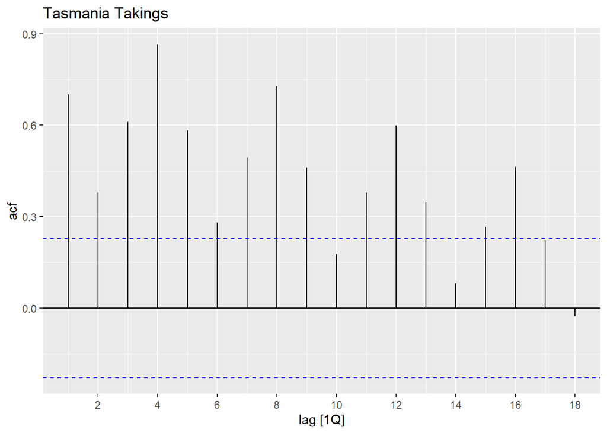

```r
  tsAcc |> ACF(Takings) %>% autoplot() + labs(title="Tasmania Takings")
```

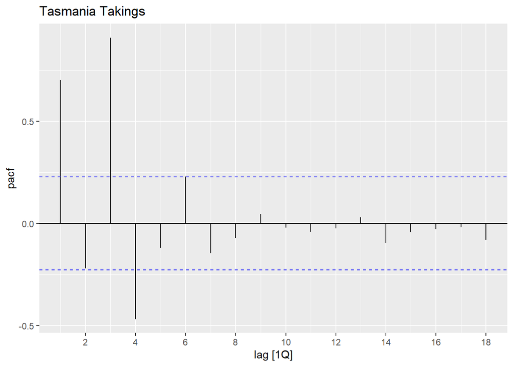

```r
  tsAcc |> PACF(Takings) %>% autoplot() + labs(title="Tasmania Takings")
```

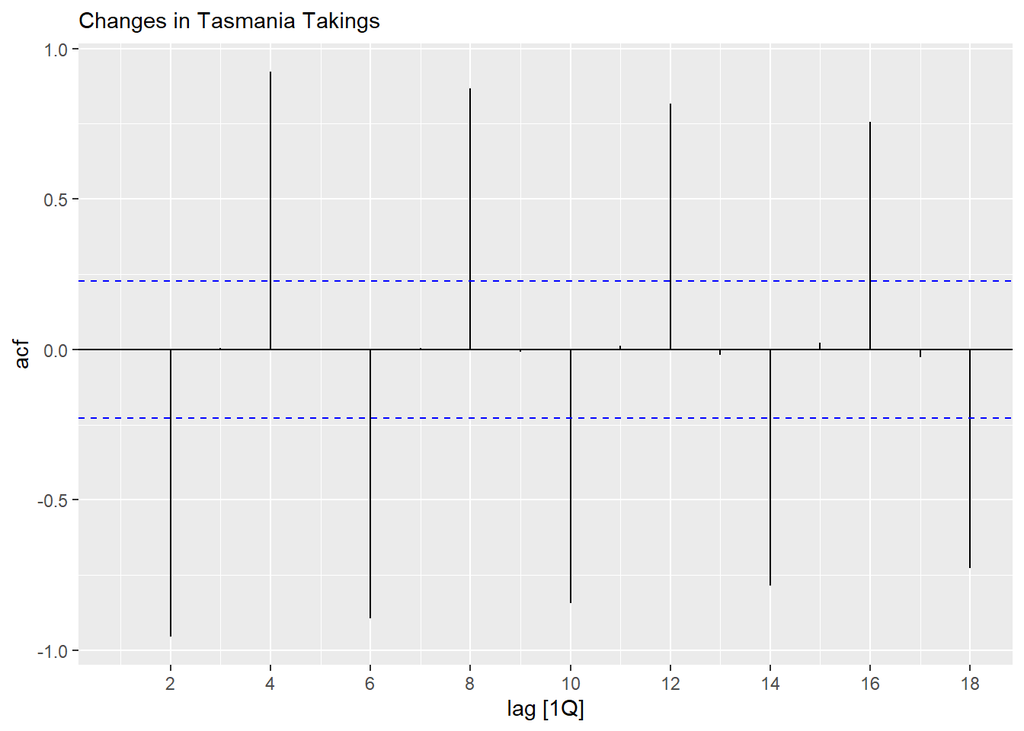

```r
  tsAcc |> ACF(difference(Takings)) |>
  autoplot() + labs(subtitle = "Changes in Tasmania Takings")
```

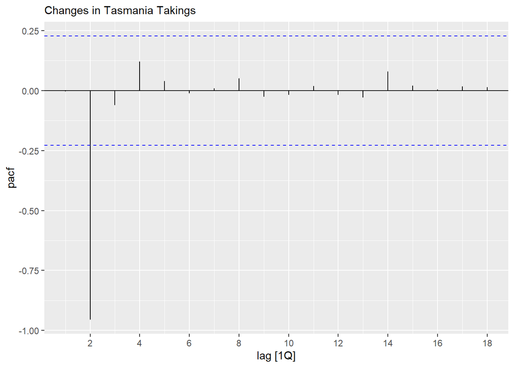

```r
  tsAcc |> PACF(difference(Takings)) |>
  autoplot() + labs(subtitle = "Changes in Tasmania Takings")
```

```r
  tsAcc |>
  mutate(diff_Takings = difference(Takings)) |>
  features(diff_Takings, ljung_box, lag = 10)
```

```
## # A tibble: 1 × 3
##   State    lb_stat lb_pvalue
##   <chr>      <dbl>     <dbl>
## 1 Tasmania    328.         0
```

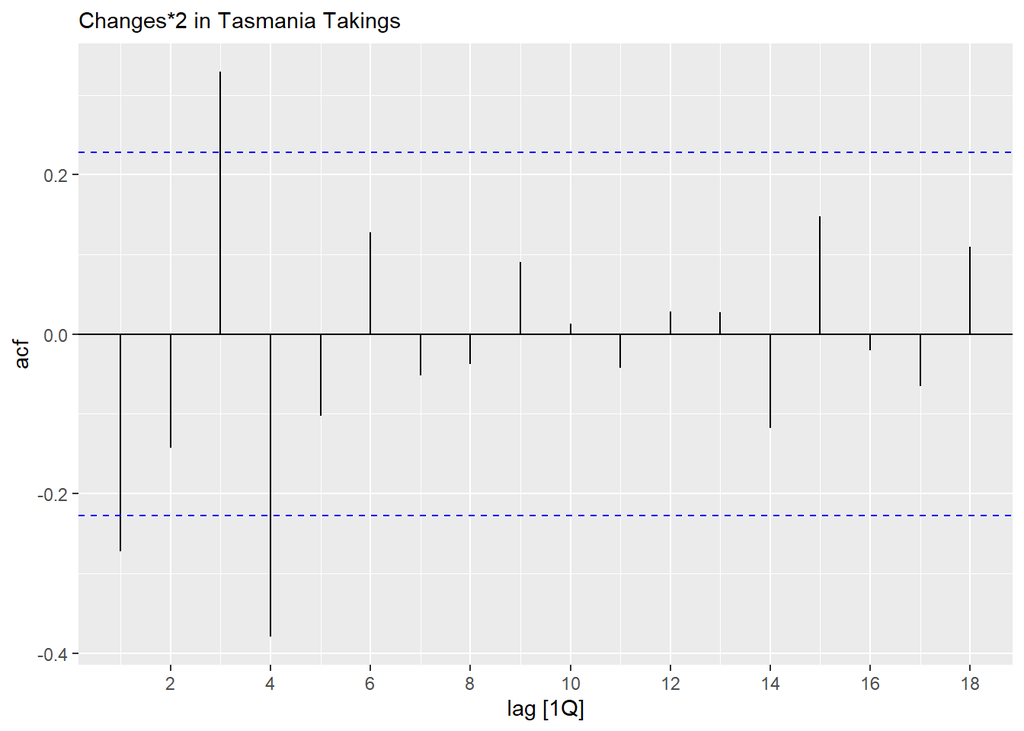

```r
  tsAcc |> ACF(difference(difference(Takings, 4), 1)) |>
  autoplot() + labs(subtitle = "Changes*2 in Tasmania Takings")
```

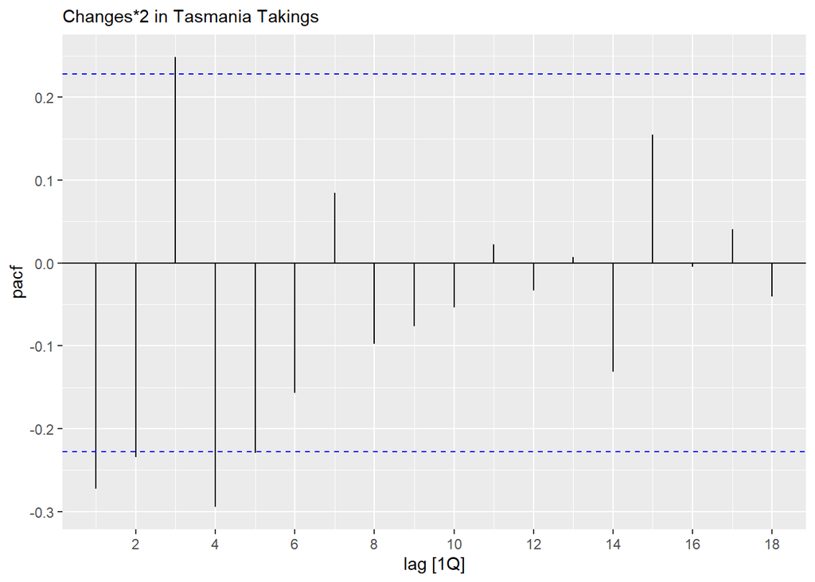

```r
  tsAcc |> PACF(difference(difference(Takings, 4), 1)) |>
  autoplot() + labs(subtitle = "Changes*2 in Tasmania Takings")
```

```r
  tsAcc |>
  mutate(diff_Takings = difference(difference(Takings, 4), 1)) |>
  features(diff_Takings, ljung_box, lag = 10)
```

```
## # A tibble: 1 × 3
##   State    lb_stat lb_pvalue
##   <chr>      <dbl>     <dbl>
## 1 Tasmania    28.8   0.00132
```

*9.3c Monthly sales from souvenirs.*

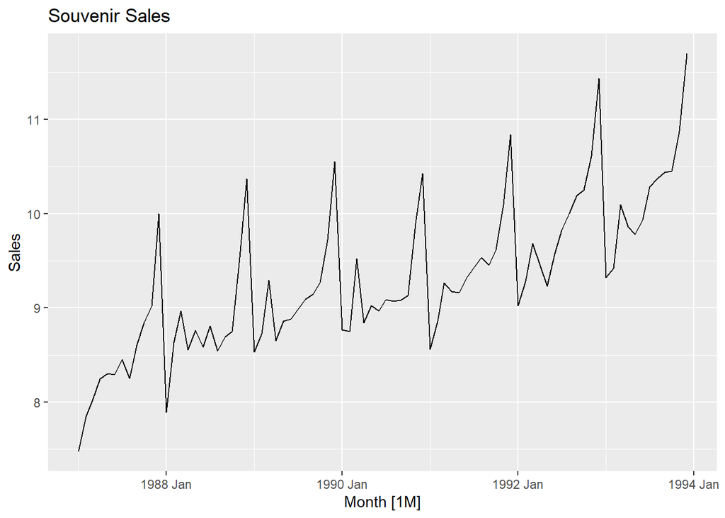

```r
tsSouvenirs <- souvenirs %>%
  mutate(Sales=box_cox(Sales, Get_lambda(souvenirs, "Sales")))

  tsSouvenirs %>% autoplot(Sales)+ labs(title="Souvenir Sales")
```

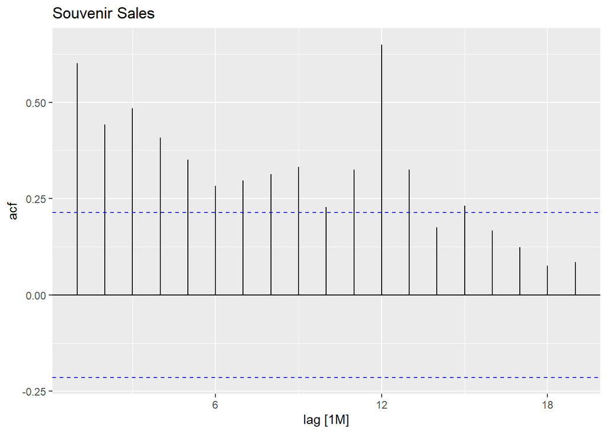

```r
  tsSouvenirs |> ACF(Sales) %>% autoplot() + labs(title="Souvenir Sales")
```

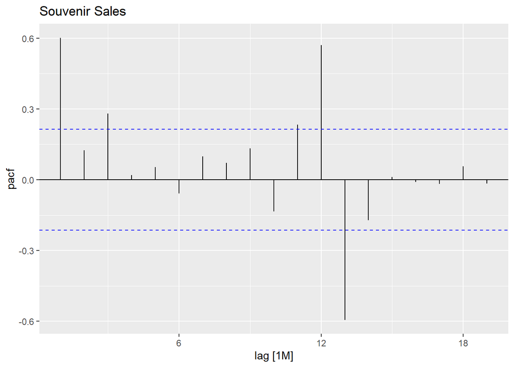

```r
  tsSouvenirs |> PACF(Sales) %>% autoplot() + labs(title="Souvenir Sales")
```

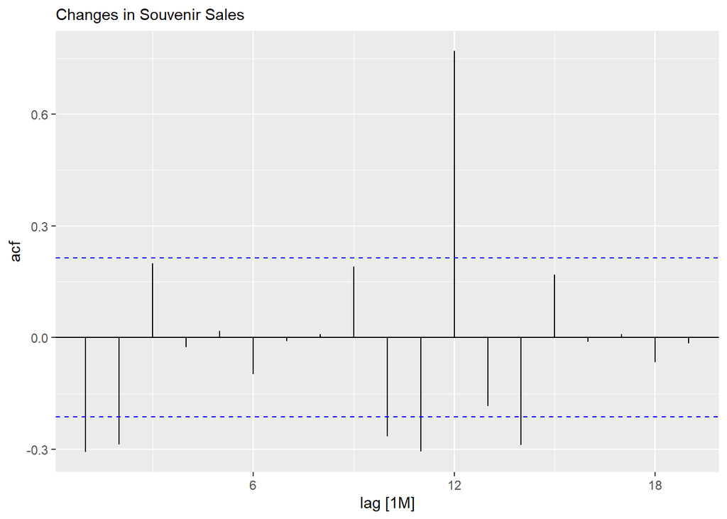

```r
  tsSouvenirs |> ACF(difference(Sales)) |>
  autoplot() + labs(subtitle = "Changes in Souvenir Sales")
```

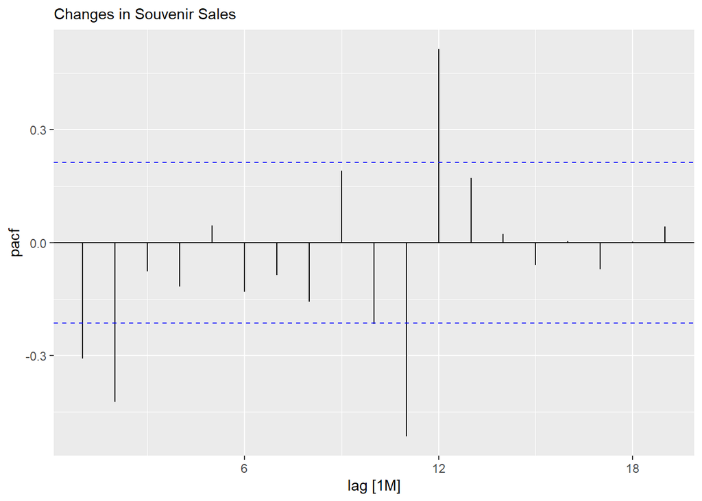

```r
  tsSouvenirs |> PACF(difference(Sales)) |>
  autoplot() + labs(subtitle = "Changes in Souvenir Sales")
```

```r
  tsSouvenirs |>
  mutate(diff_Sales = difference(Sales)) |>
  features(diff_Sales, ljung_box, lag = 10)
```

```
## # A tibble: 1 × 2
##   lb_stat lb_pvalue
##     <dbl>     <dbl>
## 1    30.1  0.000828
```

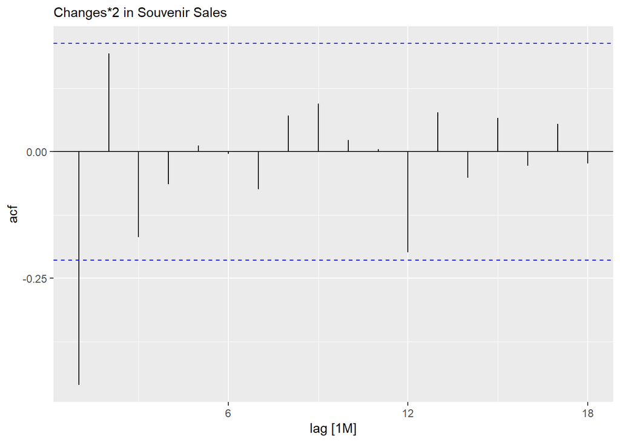

```r
  tsSouvenirs |> ACF(difference(difference(Sales, 12), 1)) |>
  autoplot() + labs(subtitle = "Changes*2 in Souvenir Sales")
```

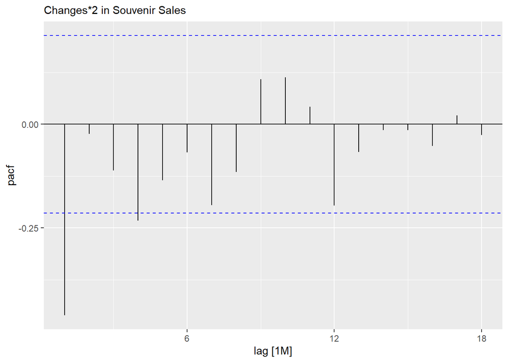

```r
  tsSouvenirs |> PACF(difference(difference(Sales, 12), 1)) |>
  autoplot() + labs(subtitle = "Changes*2 in Souvenir Sales")
```

```r
  tsSouvenirs |>
  mutate(diff_Sales = difference(Sales, 12)) |>
  features(diff_Sales, ljung_box, lag = 10)
```

```
## # A tibble: 1 × 2
##   lb_stat    lb_pvalue
##     <dbl>        <dbl>
## 1    53.7 0.0000000559
```

*9.5 For your retail data (from Exercise 8 in Section 2.10), find the appropriate order of differencing (after transformation if necessary) to obtain stationary data.*

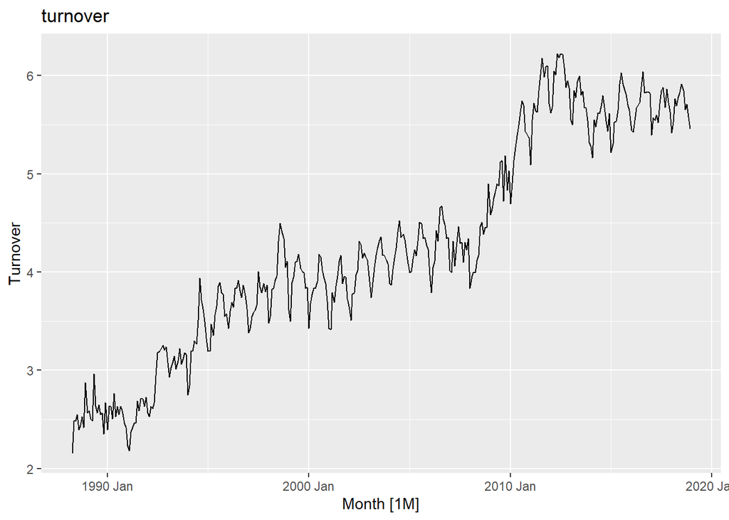

```r
set.seed(042760)
myseries <- aus_retail %>%
  filter(`Series ID` == sample(aus_retail$`Series ID`,1)) %>%
  fill_gaps() %>%
  dplyr::select(Turnover)

myseries <- myseries %>%
  mutate(Turnover=box_cox(Turnover, Get_lambda(myseries, "Turnover")))

  myseries %>% autoplot(Turnover)+ labs(title="turnover")
```

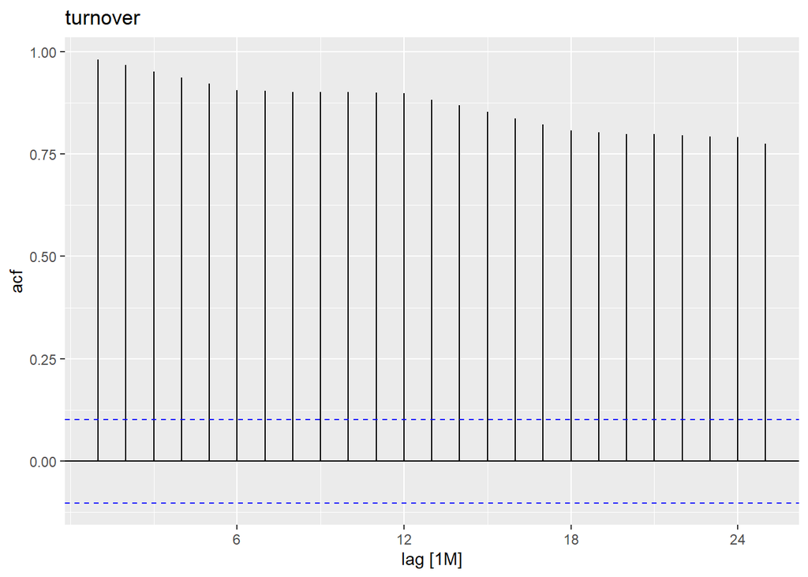

```r
  myseries |> ACF(Turnover) %>% autoplot() + labs(title="turnover")
```

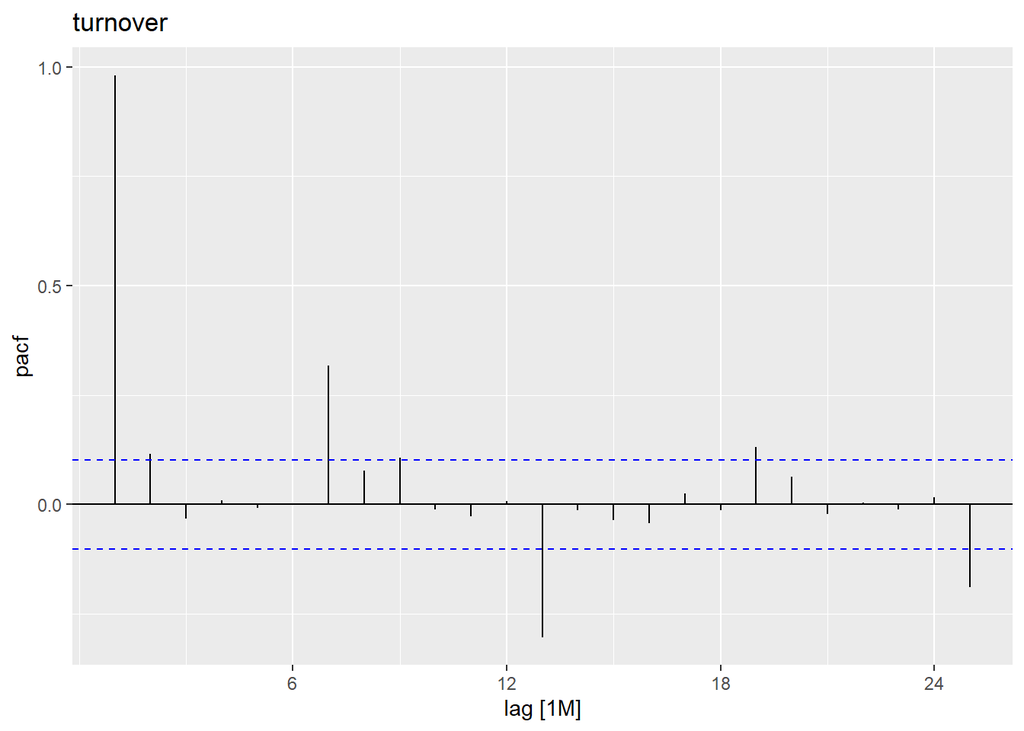

```r
  myseries |> PACF(Turnover) %>% autoplot() + labs(title="turnover")
```

```r
  forecast::ndiffs(myseries$Turnover)
```

```
## [1] 1
```

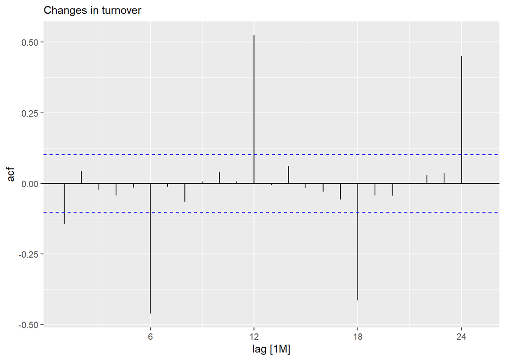

```r
  myseries |> ACF(difference(Turnover)) |>
  autoplot() + labs(subtitle = "Changes in turnover")
```

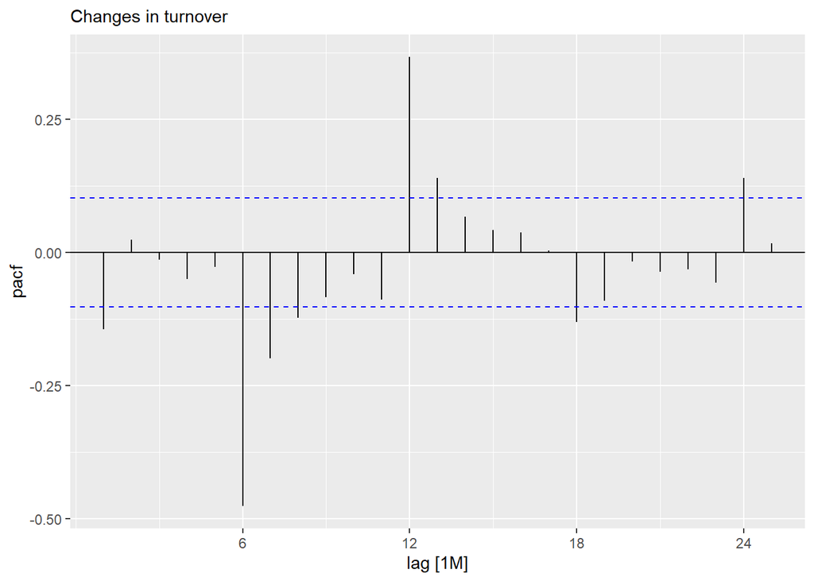

```r
  myseries |> PACF(difference(Turnover)) |>
  autoplot() + labs(subtitle = "Changes in turnover")
```

```r
  myseries |>
  mutate(diff_Turnover = difference(Turnover)) |>
  features(diff_Turnover, ljung_box, lag = 10)
```

```
## # A tibble: 1 × 2
##   lb_stat lb_pvalue
##     <dbl>     <dbl>
## 1    91.7  2.44e-15
```

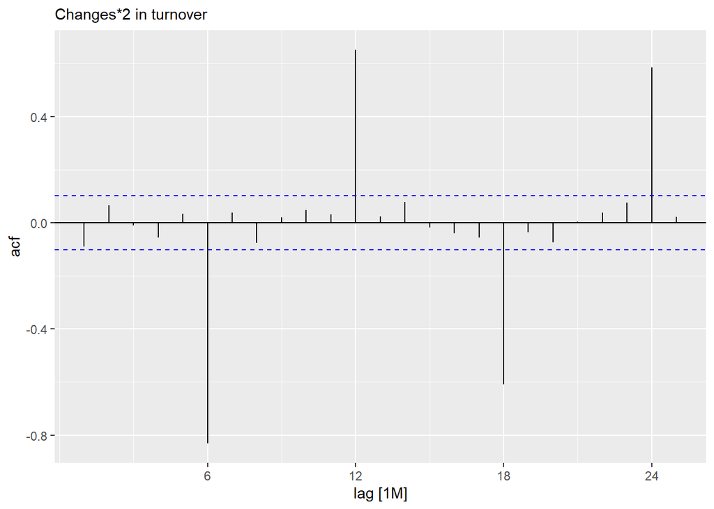

```r
  myseries |> ACF(difference(difference(Turnover, 6), 1)) |>
  autoplot() + labs(subtitle = "Changes*2 in turnover")
```

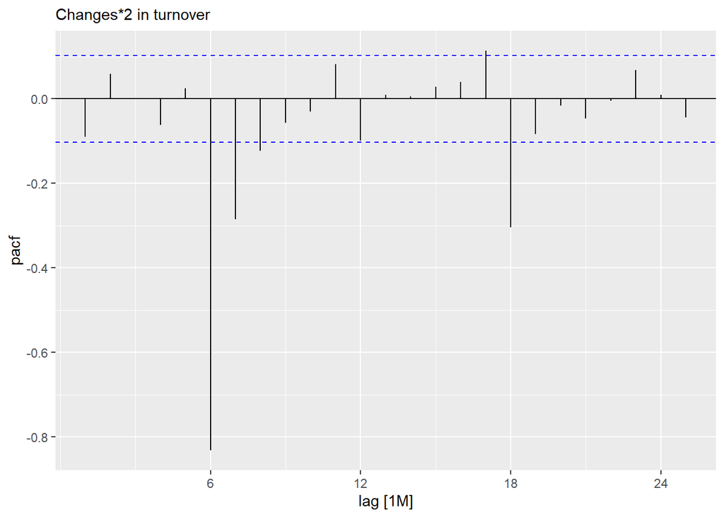

```r
  myseries |> PACF(difference(difference(Turnover, 6), 1)) |>
  autoplot() + labs(subtitle = "Changes*2 in turnover")
```

```r
  myseries |>
  mutate(diff_Turnover = difference(Turnover, 6)) |>
  features(diff_Turnover, ljung_box, lag = 10)
```

```
## # A tibble: 1 × 2
##   lb_stat lb_pvalue
##     <dbl>     <dbl>
## 1    675.         0
```

*9.6 Simulate and plot some data from simple ARIMA models.*

```r
y <- numeric(100)
e <- rnorm(100)
for(i in 2:100)
  y[i] <- 0.6*y[i-1] + e[i]
sim <- tsibble(idx = seq_len(100), y = y, index = idx)
```

*9.6b Produce a time plot for the series. How does the plot change?*

The plot becomes denser with decreasing levels of phi.

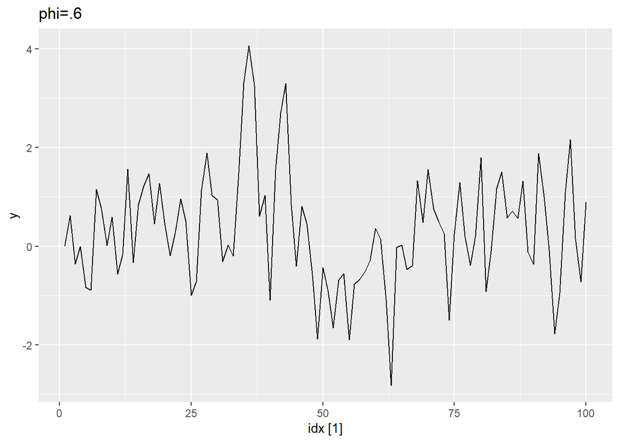

```r
autoplot(sim) +labs(title="phi=.6")
```

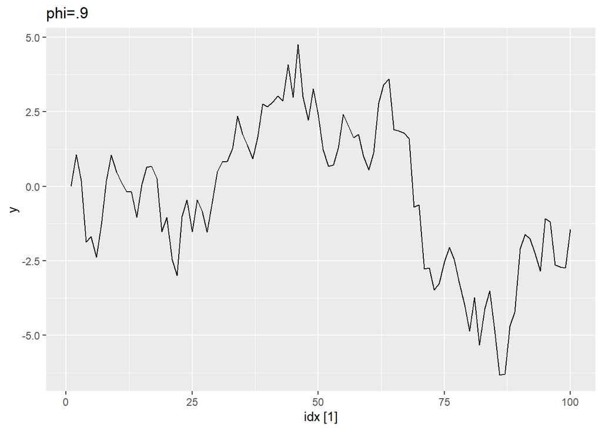

```r
y <- numeric(100)
e <- rnorm(100)
for(i in 2:100)
  y[i] <- 0.9*y[i-1] + e[i]
sim <- tsibble(idx = seq_len(100), y = y, index = idx)

autoplot(sim) +labs(title="phi=.9")
```

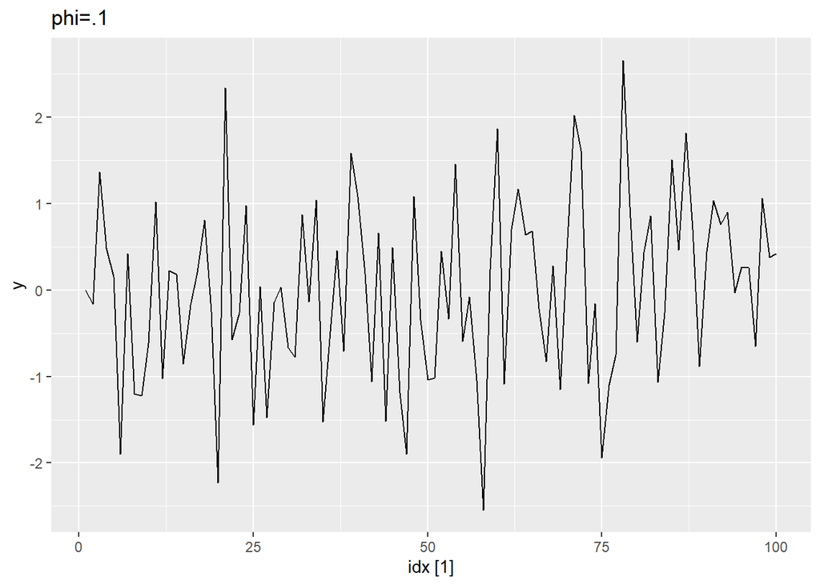

```r
y <- numeric(100)
e <- rnorm(100)
for(i in 2:100)
  y[i] <- 0.1*y[i-1] + e[i]
sim <- tsibble(idx = seq_len(100), y = y, index = idx)

autoplot(sim) +labs(title="phi=.1")
```

*9.6c Write your own code to generate data from an MA(1) model*

```r
y <- numeric(100)
e <- rnorm(100)
for(i in 2:100)
  y[i] <- e[i] + 0.6*e[i-1]
sim2 <- tsibble(idx = seq_len(100), y = y, index = idx)
```

*9.6d Produce a time plot for the series. How does the plot change?*